# Survival Analysis in R - Part 4

Source: https://www.emilyzabor.com/survival-analysis-in-r.html

```r
library(knitr)
library(dplyr)
library(survival)
library(tibble)
library(lubridate)
library(ggsurvfit)
library(tidycmprsk)
library(gtsummary)


ezfun::set_ccf_palette("contrast")
```

```
<environment: R_GlobalEnv>
```

# Part 3 Advanced Topics

1. Summary of Previous Topics:
1. The basics of survival analysis including the **Kaplan-Meier survival function** and **Cox regression**.
2. **Landmark analysis** and **time-dependent covariates**.
3. **Cumulative incidence and regression for competing risks analyses**.
2. This section covers:
1. Assessing the proportional hazards assumption.
2. Making a smooth survival plot based on x-year survival according to a continuous covariate.
3. Conditional survival.

## Assessing Proportional Hazards

1. One assumption of the Cox proportional hazards regression is that the hazards are **proportional at each point in time** throughout follow up.
2. The `cox.zph()` function from the {survival} package allows us to check this assumption. It results in two main things:
1. A hypothesis test of whether the effect of each covariate differs according to time, and a global test of all covariates at once. 1) This is done by testing for an interaction effect between the covariate and log(time). 2) A significant p-value indicates that the proportional hazards assumption is violated.
2. Plots of the Schoenfeld residuals. 1) Deviation from a zero-slope line is evidence that the proportional hazards assumption is violated.

```r
my_fit <- coxph(Surv(time, status) ~ sex + age, data = lung)

cz <- cox.zph(my_fit)
print(cz)
```

```
       chisq df    p
sex    2.608  1 0.11
age    0.209  1 0.65
GLOBAL 2.771  2 0.25
```

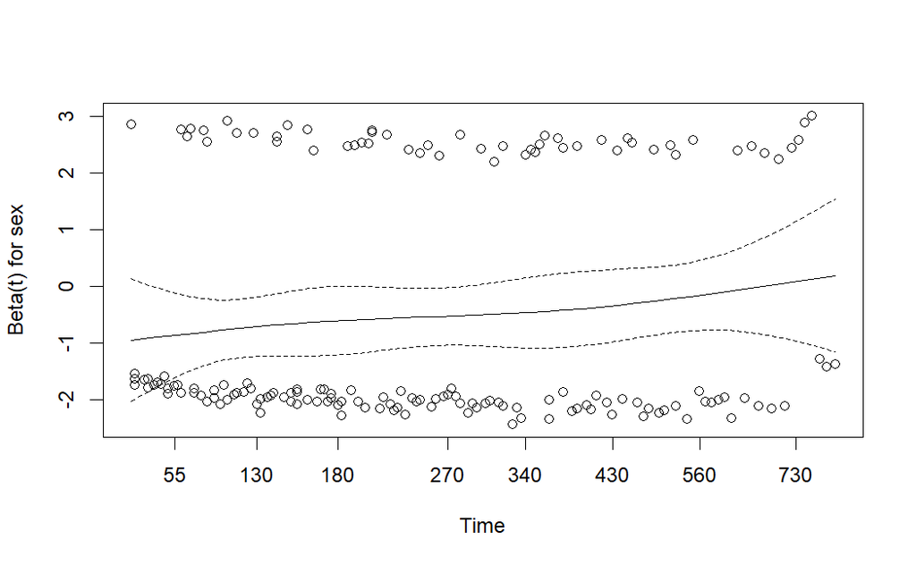

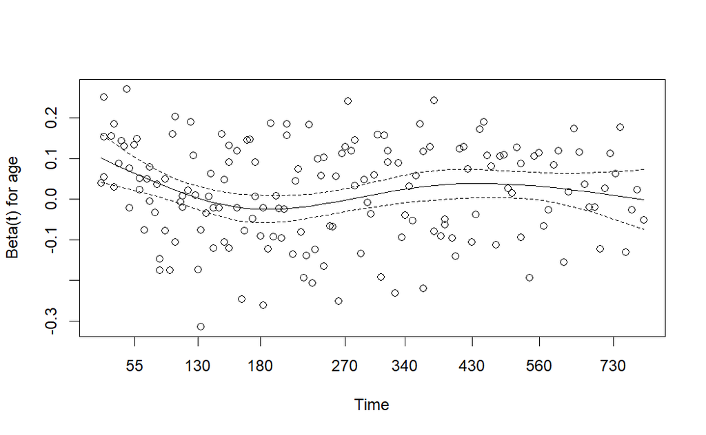

```r
plot(cz)
```

3. Here we see that both covariates sex and age have p-value > 0.05, we fail to reject the null hypothesis, and conclude that the proportional hazards assumption is satisfied for each individual covariate, and also for the model overall.

## Smooth Survival Plot

1. Sometimes you may want to visualize a survival estimate according to a continuous variable. a. The `sm.survival` function from the {sm} package allows you to do this for a quantile of the distribution of survival data.
2. The default quantile is `p = 0.5` for median interval.
2. Example: The `lung` Dataset
1. Example Data: the `lung` dataset from the {survival} package.
2. The data contain subjects with advanced lung cancer from the North Central Cancer Treatment Group.
3. Relevant Variables: - time: observed survival time in days. - status: censoring status.
   - censored = 1
   - dead = 2
     - sex:
   - male = 1
   - female = 2
4. Because the status is coded in a non-standard way in this dataset, we recode it to event = 1 and censored = 0. - The `Surv` function in the {survival} package accepts the following coding of status by default:
   - TRUE/FALSE: TRUE = event; FALSE = censored
   - 1/0: 1 = event; 0 = censored
   - 2/1: 2 = event; 1 = censored

```r
lung <- lung %>% mutate(
  status = recode(status, `1` = 0, `2` = 1)
)
```

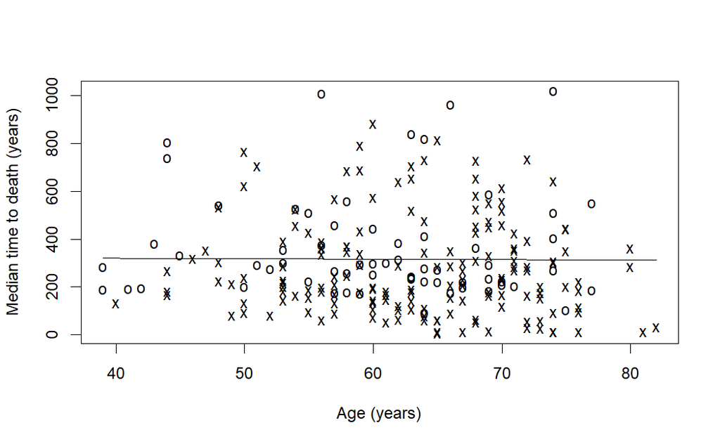

```r
library(sm)
sm.options(
  list(
    xlab = "Age (years)",
    ylab = "Median time to death (years)"
    )
)


sm.survival(
  x = lung$age,
  y = lung$time,
  status = lung$status,
  h = sd(lung$age) / nrow(lung)^(-1/4)
)
```

5. Interpretations: 1) The x’s represent events. 2) The o’s represent censoring. 3) The line is a smoothed estimate of median survival according to age.
   1. In this case, it is too smooth.
6. The option `h` is the smoothing parameter. 1) It should be related to the standard deviation of the continuous covariate, x. 2) Suggested to start with $\frac{sd(x)}{n^{-\frac{1}{4}}}$, then reduced by $\frac{1}{2}$, $\frac{1}{4}$, etc. to get a good amount of smoothing.
7. Reduce the smooth by 1/6.

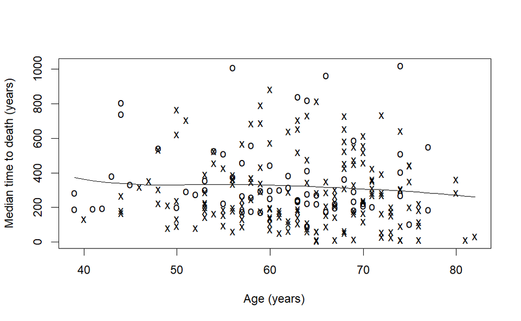

```r
sm.survival(
  x = lung$age,
  y = lung$time,
  status = lung$status,
  h = (1/6) * sd(lung$age) / nrow(lung)^(-1/4)
)
```

```
1) Now we can see that median time to death decreases slightly as age increases.
```

## Conditional Survival

1. Sometimes it is of interest to general survival estiamtes among a group of patients woh have already survived for some length of time:

$S(y|x) = \frac{S(x+y)}{S(x)}$

1. $y$: number of additional survival years of interest.
2. $x$: number of years a patient has already survived.
2. The estimates are implemented in the {condsurv} package.
1. We can use the `conditional_surv_est()` function from the {condsurv} package to get estimates and 95% confidence intervals.
2. Example: condition on survival to 6 months.

```r
library(condsurv)

fit1 <- survfit(Surv(time, status) ~ 1, data = lung)
prob_times <- seq(365.25, 182.625 * 4, 182.625)

purrr::map_df(
  prob_times,
  ~conditional_surv_est(
    basekm = fit1,
    t1 = 182.625,
    t2 = .x
  )
) %>%
  mutate(months = round(prob_times / 30.4)) %>%
  select(months, everything()) %>%
  kable
```

| months | cs_est | cs_lci | cs_uci |
| --- | --- | --- | --- |
| 12 | 0.58 | 0.49 | 0.66 |
| 18 | 0.36 | 0.27 | 0.45 |
| 24 | 0.16 | 0.10 | 0.25 |

Estimated 1-year survival:probability is approximately 40.9%.

```r
summary(survfit(Surv(time, status) ~ 1, data = lung), times = 365.25)
```

[output not shown]

```
1) The unconditional 1-year survival estiamted probability is 40.9%
3) Interpretation:
  a) Among patients who have already survived 6 months (182.625 days), the probability of being alive at 12 months (6 months later) is 58%.
  b) Among patients who have already survived 6 months, the probability of being alive at 18 months (a further 12 months) is 36%.
  c) Among patients who have already survived 6 months, the probability of being alive at 24 months (a further 18 months) is 16%.
```

3. Visualize conditional survival data based on different lengths of time survived using the `condKMggplot()` function from the {condsurv} package:

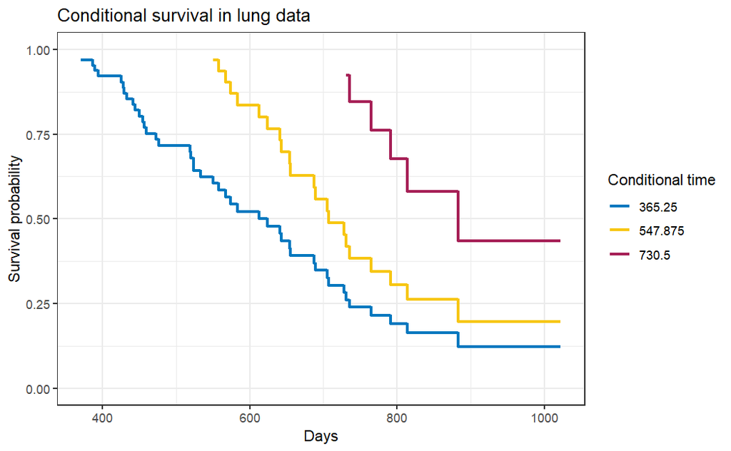

```r
gg_conditional_surv(
  basekm = fit1,
  at = prob_times,
  main = "Conditional survival in lung data",
  xlab = "Days"
) +
  labs(color = "Conditional time")
```